Correction rédigée par Téofil Adamski.

# Exercice 1

## Question 2

```python
import random


def suite_alea(n):
    suite = []
    for _ in range(n):
        x = 2 * random.random() - 1
        y = 2 * random.random() - 1
        suite.append((x, y))
    return suite

suite_alea(3)
```

```
[(-0.902657984261743, -0.04813653617765379),
 (0.5803247107153728, 0.16404462814042464),
 (0.3174107402572679, 0.2811358578913621)]
```

```python
def D(x, y):
    """Renvoie True si et seulement si le point (x, y) appartient au disque D."""
    return x^2 + y^2 <= 1

D(1/2, 1/2), D(2, 1)
```

```
(True, False)
```

```python
def nombres_points_interieurs(n):
    suite = suite_alea(n)
    N = 0
    for (x, y) in suite:
        if D(x, y):
            N += 1
    return N

n = 10^4
N = nombres_points_interieurs(n)
N
```

```
7807
```

## Question 2

```python
p = N / n
float(4 * p)
```

```
3.1228
```

## Question 4

```python
def estimation(n):
    suite = suite_alea(n)
    X = 0
    for (x, y) in suite:
        if D(x, y):
            X += x^2
    return 4 * X / n

n = 10^6
estimation(n)
```

```
0.7872908222256936
```

En utilisant un changement de variable polaire, on calcule \begin{align*} 2 \iint_{\mathbf D} x^2 \, \mathrm dx \, \mathrm dy &= \iint_{\mathbf D} x^2 \, \mathrm dx \, \mathrm dy + \iint_{\mathbf D} y^2 \, \mathrm dx \, \mathrm dy \\ &= \iint_{\mathbf D} (x^2 + y^2) \, \mathrm dx \, \mathrm dy \\ &= \int_0^1 \int_0^{2\pi} r^2 \times r \, \mathrm d\theta \, \mathrm dr \\ &= 2\pi \int_0^1 r^3 \, \mathrm dr \\ &= \frac{2\pi}{4} = \frac\pi2 \end{align*} ce qui donne $$ \iint_{\mathbf D} x^2 \, \mathrm dx \, \mathrm dy = \frac\pi4. $$

```python
pi.n() / 4
```

```
0.785398163397448
```

On peut également retrouver la valeur de cette intégrale avec Sage.

```python
from sage.symbolic.integration.integral import definite_integral


x, y = var('x, y')
definite_integral(definite_integral(x^2, y, -sqrt(1 - x^2), sqrt(1 - x^2)), x, -1, 1)
```

```
1/4*pi
```

# Exercice 2

## Question 1

Pour savoir si un rectangle $\mathscr R_{i, j}$ appartient au disque $\mathbf D$, il faut et il suffit de savoir si ses sommets y appartiennent.

```python
def rectangle_dedans(n, i, j):
    return D(i/n, j/n) and D((i - 1)/n, j/n) and \
           D(i/n, (j - 1)/n) and D((i - 1)/n, (j - 1)/n)

def nombre_rectangles_contenus(n):
    N = 0
    for i in range(-n, n + 1):
        for j in range(-n, n + 1):
            if rectangle_dedans(n, i, j):
                N += 1
    return N
```

Soit $n \geqslant 1$ un entier. On note $N_n$ le nombre de rectangles $\mathscr R_{i, j}$ contenu dans le disque $\mathbf D$. L’aire de chaque rectangle $\mathscr R_{i, j}$ vaut $1/n^2$, donc l’aire du disque $\mathbf D$ vaut approximativement $N_n/n^2$.

```python
for k in range(1, 4):
    n = 10^k
    aire = float(nombre_rectangles_contenus(n) / n^2)
    print("n =", n, ": aire =", aire)
```

```
n = 10 : aire = 2.76
n = 100 : aire = 3.1016
n = 1000 : aire = 3.137548
```

## Question 2

Pour savoir si un rectangle $\mathscr R_{i, j}$ touche le disque $\mathbf D$, il faut et il suffit de savoir si un ses sommets y appartient.

```python
def rectangle_touchant(n, i, j):
    return D(i/n, j/n) or D((i - 1)/n, j/n) or \
           D(i/n, (j - 1)/n) or D((i - 1)/n, (j - 1)/n)

def nombre_rectangles_touchant(n):
    N = 0
    for i in range(-n, n + 1):
        for j in range(-n, n + 1):
            if rectangle_touchant(n, i, j):
                N += 1
    return N


for k in range(1, 4):
    n = 10^k
    aire = float(nombre_rectangles_touchant(n) / n^2)
    print("n =", n, ": aire =", aire)
```

```
n = 10 : aire = 3.56
n = 100 : aire = 3.1816
n = 1000 : aire = 3.145548
```

## Question 3

Pour savoir si un rectangle $\mathscr R_{i, j}$ touche le bord $\mathbf S$ du disque $\mathbf D$, il faut et il suffit de savoir le nombre de ses sommets qui appartient au disque $\mathbf D$ : s’il y en a 1, 2 ou 3, alors le rectangle touche le cercle $\mathbf S$ ; sinon il ne le touche pas.

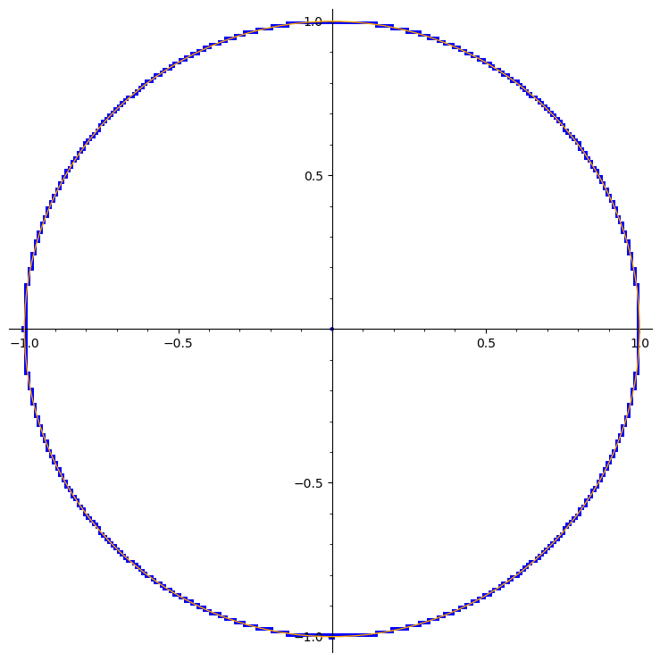

```python
def points(n, i, j):
    return [(i/n, j/n), ((i - 1)/n, j/n),
           ((i - 1)/n, (j - 1)/n), (i/n, (j - 1)/n)]

def rectangle_sur(n, i, j):
    P = points(n, i, j)
    nombre_sommets_dedans = 0
    for p in P:
        if D(p[0], p[1]):
            nombre_sommets_dedans += 1
    return 1 <= nombre_sommets_dedans <= 3

def nombres_rectangles_sur(n, affichage):
    N = 0
    fig = point((0, 0), aspect_ratio=1)
    for i in range(-n, n + 1):
        for j in range(-n, n + 1):
            if rectangle_sur(n, i, j):
                N += 1
                if affichage:
                    fig += polygon2d(points(n, i, j), fill=True, figsize=10)
    return N, fig

n = 100
N, fig = nombres_rectangles_sur(n, True)
fig + circle((0, 0), 1, color='orange')
```

```python
aire = float(N / n^2)
print("n =", n, ": aire =", aire)
```

```
n = 100 : aire = 0.08
```

# Exercice 3

```python
def suite_alea_3d(n):
    """Génère une suite aléatoire de n points du parallélépipède [-2, 2] × [-3, 3] × [-1, 1]."""
    suite = []
    for _ in range(n):
        x = 4 * random.random() - 2
        y = 6 * random.random() - 3
        z = 2 * random.random() - 1
        suite.append((x, y, z))
    return suite

def volume_ellipsoide(n):
    suite = suite_alea_3d(n)
    N = 0
    for (x, y, z) in suite:
        if x^2 / 4 + y^2 / 9 + z^2 <= 1:
            N += 1
    vol_total = 4 * 6 * 2
    return vol_total * N / n

n = 10^6
V = volume_ellipsoide(n)
V.n()
```

```
25.1336640000000
```

Par ailleurs, le volume théorique vaut $4\pi/3 \times 2 \times 3 = 8\pi$.

```python
8 * pi.n()
```

```
25.1327412287183
```

# Exercice 4

## Question 1

```python
from sage.plot.plot3d.shapes import Cylinder


t = var('t')
C = (cos(t), sin(t), 1 + cos(t)^2)
graphe = parametric_plot3d(C, (t, 0, 2 * pi), color='red')
graphe += Cylinder(1, 2)
graphe
```

[interactive chart not shown]

```python
norme_diff = norm(vector((C[0].diff(), C[1].diff(), C[2].diff())))
L = monte_carlo_integral(norme_diff, [0], [2 * pi], 10^5)
L[0]
```

```
7.641188892589633
```

## Question 2

On propose la courbe suivante.

```python
r, t = var('r, t')
C = (r * cos(t), r * sin(t), 2 - r * cos(t)^2)
fig = parametric_plot3d(C, (r, 0, 1), (t, 0, 2 * pi), color='red')
fig += Cylinder(1, 2, opacity=.3)
fig.show()
```

[interactive chart not shown]

## Question 3

```python
r, t = var('r, t')

def courbe(alpha):
    C = (r * cos(t), r * sin(t), 1 + (1 - r^alpha) / 2 + r^alpha * cos(t)^2)
    fig = parametric_plot3d(C, (r, 0, 1), (t, 0, 2 * pi), color='red')
    fig += Cylinder(1, 2, opacity=.3)
    fig.show()

courbe(1), courbe(2), courbe(3);
```

[interactive chart not shown]

## Question 5

Notons $\mathscr C_\alpha \subset \mathbf R^2$ la courbe étudiée avec $\alpha \geqslant 1$. D'abord, on veut trouver une fonction $f \colon [0, 1] \times [0, 1] \longrightarrow \mathbf R$ telle que $$ \mathscr C_\alpha = \{(x, y, f(x, y)) : x, y \in [0, 1]\}. $$ Il suffit de prendre $$ f(x, y) = 1 + \frac12(1 - (x^2 + y^2)^{\alpha/2}) + (x^2 + y^2)^{\alpha/2 - 1}x^2, \qquad x, y \in [0, 1]. $$ Ensuite, on peut calculer la surface de la courbe $\mathscr C_\alpha$ qui vaut $$ \int_0^1 \int_0^1 \sqrt{1 + \lVert\nabla f(x, y)\rVert^2} \, \mathrm dx \, \mathrm dy. $$ Puis on utilise un changement de variable polaire.

```python
x, y = var('x, y')
r, t = var('r, t')

def surface(alpha):
    r2 = x^2 + y^2
    f = 1 + (1 - r2^(alpha / 2)) / 2 + r2^(alpha / 2 - 1) * x^2
    g = sqrt(1 + norm(f.gradient())^2)
    integrande = g(x=r * cos(t), y=r * sin(t)) * r
    return monte_carlo_integral(integrande, [0, 0], [1, 2 * pi], 10^5)[0]

surface(1), surface(2), surface(3)
```

```
(3.9967888597807018, 3.8352673351205073, 3.8563039760860707)
```

Le toit pour $\alpha = 2$ coûte le moins cher.